# Принятие бизнес-решения на основе оценки результатов A/B-теста.

### 2. Ранжирование гипотез в порядке приоритета

#### 2.1. Применим фреймворк ICE для приоритизации гипотез. Отсортируем гипотезы по убыванию приоритета.

```python
hypothesis['ice'] = round((hypothesis['impact']*hypothesis['confidence'])/(hypothesis['efforts']), 1)
display(hypothesis[['hypothesis', 'ice']].sort_values(by='ice', ascending=False))
```

|  | hypothesis | ice |
| --- | --- | --- |
| 8 | Запустить акцию, дающую скидку на товар в день рождения | 16.2 |
| 0 | Добавить два новых канала привлечения трафика, что позволит привлекать на 30% больше пользователей | 13.3 |
| 7 | Добавить форму подписки на все основные страницы, чтобы собрать базу клиентов для email-рассылок | 11.2 |
| 6 | Показать на главной странице баннеры с актуальными акциями и распродажами, чтобы увеличить конверсию | 8.0 |
| 2 | Добавить блоки рекомендаций товаров на сайт интернет магазина, чтобы повысить конверсию и средний чек заказа | 7.0 |
| 1 | Запустить собственную службу доставки, что сократит срок доставки заказов | 2.0 |
| 5 | Добавить страницу отзывов клиентов о магазине, что позволит увеличить количество заказов | 1.3 |
| 3 | Изменить структура категорий, что увеличит конверсию, т.к. пользователи быстрее найдут нужный товар | 1.1 |
| 4 | Изменить цвет фона главной страницы, чтобы увеличить вовлеченность пользователей | 1.0 |

#### 2.2. Применим фреймворк RICE для приоритизации гипотез. Отсортируем гипотезы по убыванию приоритета.

```python
hypothesis['rice'] = (hypothesis['reach']*hypothesis['impact']*hypothesis['confidence'])/(hypothesis['efforts'])
display(hypothesis[['hypothesis', 'rice', 'ice']].sort_values(by='rice', ascending=False))
```

|  | hypothesis | rice | ice |
| --- | --- | --- | --- |
| 7 | Добавить форму подписки на все основные страницы, чтобы собрать базу клиентов для email-рассылок | 112.0 | 11.2 |
| 2 | Добавить блоки рекомендаций товаров на сайт интернет магазина, чтобы повысить конверсию и средний чек заказа | 56.0 | 7.0 |
| 0 | Добавить два новых канала привлечения трафика, что позволит привлекать на 30% больше пользователей | 40.0 | 13.3 |
| 6 | Показать на главной странице баннеры с актуальными акциями и распродажами, чтобы увеличить конверсию | 40.0 | 8.0 |
| 8 | Запустить акцию, дающую скидку на товар в день рождения | 16.2 | 16.2 |
| 3 | Изменить структура категорий, что увеличит конверсию, т.к. пользователи быстрее найдут нужный товар | 9.0 | 1.1 |
| 1 | Запустить собственную службу доставки, что сократит срок доставки заказов | 4.0 | 2.0 |
| 5 | Добавить страницу отзывов клиентов о магазине, что позволит увеличить количество заказов | 4.0 | 1.3 |
| 4 | Изменить цвет фона главной страницы, чтобы увеличить вовлеченность пользователей | 3.0 | 1.0 |

#### 2.3.Рассмотрим, как изменилась приоритизация гипотез при применении фреймфорка RICE вместо ICE.

*Подитог раздела 2 Ранжирование гипотез:*  
При применении фреймворка ICE для приоретизации гипотез в таблице выше, высший приоритет получили гипотезы 8, 0, 7. При применении фреймворка RICE для приоретизации гипотез, высший приоритет получили гипотезы 7, 2, 0, 6. Разница в фреймфорках заключается в учете числа пользователей, которых предполагаемое изменение затронет (охват). Поэтому если охват учитывается (RICE), то более приоритетными становятся гипотезы 7, 2, 0, 6.  
В обоих фреймворках среди наиболее приоритетных гипотез находятся гипотезы 0 и 7.

### 3. Анализ проведенного A/B-теста и полученных результатов (из файлов orders.csv и visitors.csv):

#### 3.1. Построим график кумулятивной выручки по группам.

```python
# создаем массив уникальных пар значений дат и групп теста
datesGroups = orders[['date','group']].drop_duplicates()

# получаем агрегированные кумулятивные по дням данные о заказах
ordersAggregated = datesGroups.apply(lambda x: orders[np.logical_and(orders['date'] <= x['date'], orders['group'] ==
x['group'])].agg({'date' : 'max', 'group' : 'max', 'transactionid' : 'nunique', 'visitorid' : 'nunique', 'revenue' : 'sum'}),
axis=1).sort_values(by=['date','group'])

# получаем агрегированные кумулятивные по дням данные о посетителях интернет-магазина
visitorsAggregated = datesGroups.apply(lambda x: visits[np.logical_and(visits['date'] <= x['date'], visits['group'] ==
     x['group'])].agg({'date' : 'max', 'group' : 'max', 'visitors' : 'sum'}), axis=1).sort_values(by=['date','group'])

# объединяем кумулятивные данные в одной таблице и присваиваем ее столбцам понятные названия
cumulativeData = ordersAggregated.merge(visitorsAggregated, left_on=['date', 'group'], right_on=['date', 'group'])
cumulativeData.columns = ['date', 'group', 'orders', 'buyers', 'revenue', 'visitors']

print(cumulativeData.head())
```

```
        date group  orders  buyers  revenue  visitors
0 2019-08-01     A      24      20   148579       719
1 2019-08-01     B      21      20   101217       713
2 2019-08-02     A      44      38   242401      1338
3 2019-08-02     B      45      43   266748      1294
4 2019-08-03     A      68      62   354874      1845
```

Построим графики кумулятивной выручки по дням и группам A/B-тестирования:

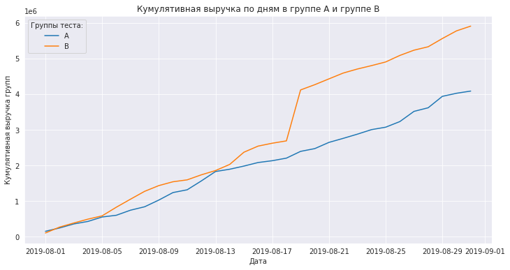

```python
# датафрейм с кумулятивным количеством заказов и кумулятивной выручкой по дням в группе А
cumulativeRevenueA = cumulativeData[cumulativeData['group']=='A'][['date','revenue', 'orders']]

# датафрейм с кумулятивным количеством заказов и кумулятивной выручкой по дням в группе B
cumulativeRevenueB = cumulativeData[cumulativeData['group']=='B'][['date','revenue', 'orders']]

plt.figure(figsize=(12, 6))
# Строим график выручки группы А
plt.plot(cumulativeRevenueA['date'], cumulativeRevenueA['revenue'], label='A')

# Строим график выручки группы B
plt.plot(cumulativeRevenueB['date'], cumulativeRevenueB['revenue'], label='B')
plt.legend(title='Группы теста:')
plt.xlabel('Дата')
plt.ylabel('Кумулятивная выручка групп')
plt.title('Кумулятивная выручка по дням в группе А и группе B');
```

Кумулятивные выручки обеих группп растут почти равномерно. В группе B был небольшой период (18-19 августа) резкого роста выручки (большие заказы или большое количество заказов). Выручка группы В стабильно больше выручки группы А.

#### 3.2. Постром график кумулятивного среднего чека по группам.

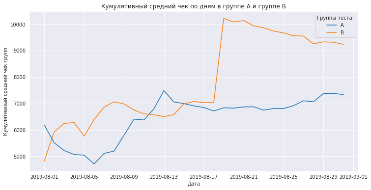

```python
plt.figure(figsize=(12, 6))
plt.plot(cumulativeRevenueA['date'], cumulativeRevenueA['revenue']/cumulativeRevenueA['orders'], label='A')
plt.plot(cumulativeRevenueB['date'], cumulativeRevenueB['revenue']/cumulativeRevenueB['orders'], label='B')
plt.legend(title='Группы теста:')
plt.xlabel('Дата')
plt.ylabel('Кумулятивный средний чек групп')
plt.title('Кумулятивный средний чек по дням в группе А и группе B');
```

Графики средних чеков обеих групп до 19 августа сильно менялись. Ососбенно 18-19 августа были сильные изменения в среднем чеке группы B. После 19 августа средний чек групп стал более равномерным. При этом в группе В он продолжает падать с 19 августа, а в группе А он установился в районе 7000.  
Средний чек группы В выше среднего чека группы А.

#### 3.3. Построим график относительного изменения кумулятивного среднего чека группы B к группе A.

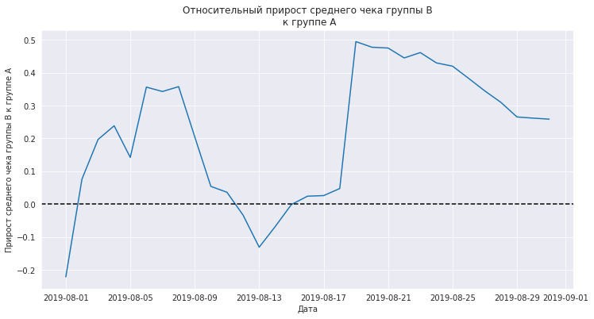

```python
# собираем данные в одном датафрейме
mergedCumulativeRevenue = cumulativeRevenueA.merge(cumulativeRevenueB, left_on='date', right_on='date', how='left',
                                                   suffixes=['A', 'B'])
plt.figure(figsize=(12, 6))
# cтроим отношение средних чеков
plt.plot(mergedCumulativeRevenue['date'], (mergedCumulativeRevenue['revenueB']/mergedCumulativeRevenue['ordersB'])/
         (mergedCumulativeRevenue['revenueA']/mergedCumulativeRevenue['ordersA'])-1)

# добавляем ось X
plt.axhline(y=0, color='black', linestyle='--')
plt.xlabel('Дата')
plt.ylabel('Прирост среднего чека группы В к группе А')
plt.title('Относительный прирост среднего чека группы В\n к группе А');
```

График различия среднего чека между сегментами резко «скачет» в нескольких местах. Скорее всего, это влияние крупных заказов и выбросов. Текущий график показывает, что средний чек у группы В больше, чем средний чек группы А.

#### 3.4. Построить график кумулятивного среднего количества заказов на посетителя по группам. Сделать выводы и предположения.

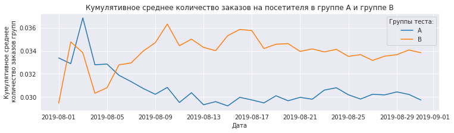

```python
# считаем кумулятивное среднее количества заказов на посетителя
cumulativeData['conversion'] = cumulativeData['orders']/cumulativeData['visitors']

# отделяем данные по группе A
cumulativeDataA = cumulativeData[cumulativeData['group']=='A']

# отделяем данные по группе B
cumulativeDataB = cumulativeData[cumulativeData['group']=='B']

plt.figure(figsize=(12, 3))
# строим графики
plt.plot(cumulativeDataA['date'], cumulativeDataA['conversion'], label='A')
plt.plot(cumulativeDataB['date'], cumulativeDataB['conversion'], label='B')
plt.legend(title='Группы теста:')
plt.xlabel('Дата')
plt.ylabel('Кумулятивное среднее\n количество заказов групп')
plt.title('Кумулятивное среднее количество заказов на посетителя в группе А и группе B');
```

Кумулятивное среднее количество заказов на посетителя в группе А и В зафиксировалось.  
При этом с 06 августа среднее количество заказов на посетителя в группе В стабильно выше, чем в группе А.